# A Minimal RAG, From PDF to Highlighted Answer

The smallest version of RAG that actually works, on a real PDF, with grounded answers and the source lines highlighted.

## 1. What we’re building

The pipeline has four bricks (the four pillars Part II will develop in depth) plus a final, optional rendering step. Each brick says what it takes in and what it gives back; what crosses the line between two bricks is what we save.

1. **Document parsing.** *In:* a PDF path. *Out:* `line_df` (one row per text line, with `page_num`, `line_num`, `text`, and the bounding box) plus a `page_df`. Bigger systems save both to a database table.
2. **Question parsing.** *In:* a text question. *Out:* a `ParsedQuestion` (the normalized question + a short list of checked keywords). Does not know about retrieval — it does **not** compute the question embedding.
3. **Retrieval.** *In:* the `ParsedQuestion`. *Out:* top-k **page numbers** (and, optionally, the matching line numbers within those pages). Saving only the page numbers keeps the handoff small; the next step rebuilds the filtered lines from `line_df` on the spot. The question embedding lives in this brick because it depends on the corpus index.
4. **Generation.** *In:* the question, `line_df`, and the retrieved page numbers. *Out:* an `AnswerWithEvidence` — a typed JSON with the answer, the evidence span `(start_page, start_line, end_page, end_line)`, a confidence, a justification, the exact quotes from the source, and any caveats. The full JSON is worth saving for evaluation, audit, and replay.
5. **PDF annotation (optional).** *In:* the source PDF and the evidence span. *Out:* an annotated PDF with rectangles drawn around the cited lines. Skip this step in a CLI tool, a batch job, or an API; the answer with citations is already complete after step 4.

The first four are the four pillars (Article 5 develops document parsing, Article 6 develops question parsing, Article 7 retrieval, Article 8 generation). PDF annotation is the rendering step — a way to show the citation back on the source — not a pillar in itself. The diagram below sets it apart visually: blue for the four pillars, violet for the downstream rendering, slightly offset to read “side step, not next pillar”.

The shape of the pipeline, end to end, with the saved data named on each arrow:

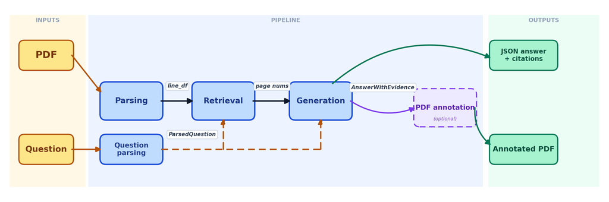

*Caption — pipeline_matplotlib.png: The five-brick pipeline with the saved data named on every arrow (line_df, ParsedQuestion, page nums, AnswerWithEvidence). PDF and Question on the left, JSON answer and annotated PDF on the right. Three zones (amber inputs, blue pipeline, emerald outputs), with violet marking PDF annotation as the optional downstream rendering step.*

A PDF and a question go in. Each brick turns its input into something more structured: document parsing turns the PDF into rows, question parsing turns the question into search-ready keywords, retrieval cuts the rows down to a few page numbers, generation produces a typed answer, and PDF annotation draws the cited lines back onto the source. What comes out is not a chatbot bubble. It’s a sourced JSON answer plus an annotated PDF you can open and check.

The dependencies are minimal: **pymupdf** (parses PDFs into text plus position info; the bounding boxes it returns are what let us highlight the answer back on the source page), **openai** (LLM client; via `base_url` the same library serves Azure, OpenRouter, Ollama, or any compatible endpoint), **pandas** (holds the document as a DataFrame, the format every parsing and retrieval step uses), **pydantic** (defines the answer schema that forces structured JSON with citations).

No vector database, no orchestration framework, no specialized RAG library. Later articles look at when those libraries’ helpers become useful, and when they get in the way of seeing what’s going on.

## 2. The four bricks (plus PDF annotation)

The next six subsections walk through each brick — the four pillars (document parsing, question parsing, retrieval, generation) plus the optional PDF annotation step. Each subsection ends with the actual output it produces on the *Attention* paper. Chaining the bricks into one function and testing the whole pipeline on a second document is the next section, §3.

A principle that runs through every brick: **each step explicitly declares its inputs and outputs, and the steps are independent**. The output of step N is the input of step N+1, saved as a named DataFrame (or, at larger scale, written to a database table) so any step can be re-run on its own against the saved output of the previous one. This is plain old separation of concerns, but it’s worth restating loudly. In the AI-coding era, an assistant told to “fix retrieval” can quietly modify the question parser when it should have stayed untouched. Independent modules are how you work confidently on one piece without breaking the rest.

Every subsection below opens with a hook sentence, then an explicit `> **In:** … **Out:** …` line so the contract is impossible to miss.

### 2.1 Setup

Imports, OpenAI client, paths. The `base_url` parameter lets the same code run against OpenAI, Azure, OpenRouter, Ollama, or any compatible endpoint, which is the realistic case in production deployments. The model name `gpt-4.1` is a placeholder for “a capable instruct-tuned model with structured output support”; substitute the equivalent for your provider.

```python
import json

import pandas as pd
import numpy as np
import fitz

from docintel.parsing.pdf import fitz_pdf_to_line_df, build_page_df
from docintel.question import parse_question
from docintel.retrieval import (
    find_matching_keywords,
    retrieve_pages,
    retrieve_pages_by_similarity,
)
from docintel.core import embed_page_df
from docintel.generation import AnswerWithEvidence, llm_answer_with_evidence
from docintel.annotation import (
    passage_lines_df_from_answer,
    passage_bbox_by_page,
    draw_passage_rectangles,
)
```

```python
import os
from openai import OpenAI
from dotenv import load_dotenv

load_dotenv()

client = OpenAI(
    api_key=os.getenv("API_KEY"),
    base_url=os.getenv("BASE_URL"),
)
model_chat = os.getenv("MODEL_CHAT", "gpt-4.1")
model_embed = os.getenv("MODEL_EMBED", "text-embedding-3-small")
```

```python
# Edit this path to point at any PDF in data/.
pdf_path = REPO_ROOT / "data" / "paper" / "1706.03762v7.pdf"
output_folder = REPO_ROOT / "output" / "paper" / pdf_path.stem
output_folder.mkdir(parents=True, exist_ok=True)

print(f"PDF:    {pdf_path.relative_to(REPO_ROOT)}  (exists: {pdf_path.exists()})")
print(f"Output: {output_folder.relative_to(REPO_ROOT)}")
```

```
PDF:    data\paper\1706.03762v7.pdf  (exists: True)
Output: output\paper\1706.03762v7
```

### 2.2 Document parsing

We extract every text line of the PDF along with its position on the page. The output is a DataFrame where each row is one line, with `page_num`, `line_num`, the text itself, and the four bounding-box coordinates `x0, y0, x1, y1`.

> - **In:** a PDF path.
> - **Out:** `line_df` (one row per text line, with `page_num`, `line_num`, `text`, and the bounding box) plus a `page_df` we’ll build in §2.4.

In bigger systems we save both DataFrames plus a small JSON summary to a database, so the rest of the pipeline reads the saved parse instead of opening the PDF again every time.

The bounding boxes matter because we use them to draw highlights at the end. Without them, we could say “page 8, line 12” but we couldn’t show the user where on the page that line is.

```python
line_df = fitz_pdf_to_line_df(pdf_path)
print(f"{len(line_df)} lines across {line_df['page_num'].nunique()} pages")
line_df.head()
```

```
1048 lines across 15 pages
```

|  | page_num | line_num | text | x0 | y0 | x1 | y1 | character_count |
| --- | --- | --- | --- | --- | --- | --- | --- | --- |
| 0 | 1 | 1 | Provided proper attribution is provided, Googl... | 124.666000 | 72.896317 | 487.338959 | 84.851517 | 75 |
| 1 | 1 | 2 | reproduce the tables and figures in this paper... | 124.313004 | 86.843338 | 487.894501 | 98.798538 | 80 |
| 2 | 1 | 3 | scholarly works. | 267.593994 | 100.791336 | 346.498322 | 112.746536 | 16 |
| 3 | 1 | 4 | Attention Is All You Need | 211.488007 | 148.829880 | 399.893494 | 166.045273 | 25 |
| 4 | 1 | 5 | Ashish Vaswani∗ | 132.908005 | 233.539398 | 203.886673 | 245.011124 | 15 |

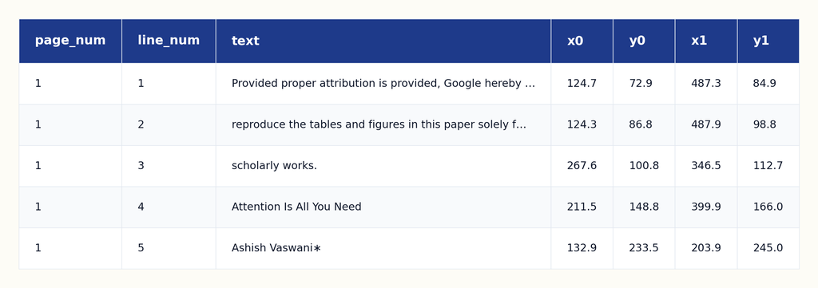

*Caption — line_df_head.png: First five rows of line_df. Each row is one text line of the PDF with its page, line number, the text itself, and the bounding box used later for highlighting.*

The paper, turned into rows. There it is: copyright notice, title, first author. Each line of the paper is one row, with its text and the four numbers that locate it on the page. Those `x0, y0, x1, y1` columns are abstract right now; in §2.6 they’re what lets us draw rectangles on the source PDF, exactly over the lines the model cited.

**This DataFrame, `line_df`, is the atomic data structure of the rest of the series.** Article 5 will introduce a richer relational model around it (TextDF, ChunkDF, TocDF, PageDF), but the fundamental idea starts here: represent the document as a structured table where each row is a line with metadata.

For the question we’ll ask in this article, none of this matters. For other questions on the same paper, it will. Article 5 is dedicated to parsing in earnest.

### 2.3 Question parsing

Before the question goes to retrieval, we run it through a tiny LLM call. The goal is to extract the **keywords most useful for searching the document**: short phrases the document is likely to use, not necessarily the literal words of the question.

> - **In:** a text question.
> - **Out:** a `ParsedQuestion` holding the normalized question and a short list of checked keywords.

**This step does not know about retrieval.** It does not care whether the next step uses keyword matching, embeddings, or a mix. It also does *not* compute the question embedding. That one is tied to the corpus index, so it lives in the retrieval module (§2.4). Keep that line clean and you can swap the embedding model or add a hybrid retriever tomorrow without touching question parsing.

Why bother on a minimal pipeline? Two reasons.

First, **you can explain why retrieval picked what it picked**. When the system answers correctly, we can see which keywords drove the search. When it answers wrong, we can see whether the keywords were off (a question-parsing problem) or the right keywords landed on the wrong page (a retrieval problem). Without question parsing, retrieval is a black box.

Second, **the question is a real input, just like the document**. §2.2 parsed the document into a structured `line_df`. This subsection parses the question into a structured `ParsedQuestion`. Both inputs deserve to be parsed before they hit the search step. Article 6 builds the richer version (intent, splitting compound questions, expected answer shape, scope filters); the minimal version below is the smallest version of the same brick.

```python
question = "What are the options mentioned for positional encoding?"
parsed_question = parse_question(question, client=client)
print(parsed_question.keywords)
```

```
['positional encoding']
```

The LLM produces a single, literal phrase like `['positional encoding']`. That’s deliberate. An earlier draft of this prompt asked for “3 to 5 short keywords useful for searching”, and the LLM dutifully filled the quota with paraphrases (`positional encoding options`, `types of positional encoding`, `transformer positional encoding`). None of those are written in the document — only `positional encoding` is. Substring matching is brutal: a single missing word kills the match. The minimal version asks the LLM to *do less* — extract the literal noun phrase, drop the question framing — and trusts the next block to take it from there.

**Overriding the system prompt.** `parse_question` exposes the system prompt as a kwarg with `PARSE_QUESTION_PROMPT` as default. To test a variant — different domain, stricter rules, extra examples — pass `system_prompt=...` at the call site. No edit to the function. Same pattern for every LLM helper in `docintel` (`llm_answer_with_evidence` exposes both `system_prompt` and `user_template`).

Below: the same `parse_question` call, run twice on a *contract*-style question. First with the research-paper default — generic. Then with a contract-domain prompt — picks up insurance vocabulary like `exclusions`, `deductible`.

```python
from docintel.question import PARSE_QUESTION_PROMPT

demo_question = "Are earthquakes excluded from coverage?"

# Default: research-paper prompt.
parsed_question_default = parse_question(demo_question, client=client)
print("Default (research-paper):", parsed_question_default.keywords)

# Override: insurance / legal contract prompt.
contract_prompt = (
    "Extract 1 to 3 short keywords from the user question for searching an "
    "insurance contract or legal policy. Prefer literal terms the contract is "
    "likely to use: clauses, exclusions, named perils, deductibles, caps. Drop "
    "question framing words. Output 1 to 3 keywords."
)
parsed_question_contract = parse_question(
    demo_question, system_prompt=contract_prompt, client=client,
)
print("Contract prompt:        ", parsed_question_contract.keywords)
```

```
Default (research-paper): ['earthquakes', 'coverage']
Contract prompt:         ['earthquakes', 'coverage', 'exclusions']
```

A note on what this minimal version doesn’t do. It doesn’t detect intent (Q&A vs summarization vs translation). It doesn’t decompose compound questions (“what is X *and* what is Y”). It doesn’t surface an `expected_answer_shape` to drive the generation template. It doesn’t pull from a domain glossary of expert keywords. All of these are Article 6 territory. Here we keep one field, `keywords`, because that’s the smallest version that makes the brick visible. The next subsection feeds those keywords straight into a transparent, no-vector retrieval.

### 2.4 Retrieval

Sending all 1048 lines to the LLM would work on a paper this size, but it does not scale to longer documents and it spreads the model’s attention too thin. We need to cut the document down to the few pages most likely to contain the answer.

> - **In:** the checked keywords (and/or the normalized question, depending on the method) from §2.3.
> - **Out:** the top-k **page numbers**, plus optionally the matching line numbers within those pages.

What we save is just *page numbers*: small, cheap, easy to read. Generation in §2.5 builds the `filtered_line_df` on the spot by filtering `line_df` to those pages; saving the filtered DataFrame would be more data than we need to keep around.

The question embedding is computed here, not in §2.3, because an embedding only makes sense against the same index it was built against (the corpus index). Same logic for any hybrid scoring or BM25 statistics: they belong here.

The standard answer in 2024 RAG tutorials is **embeddings**: turn each page into a vector, turn the question into a vector, score by cosine similarity. We’ll use embeddings later in the series (Article 2 is dedicated to them). For the minimal version, we deliberately don’t, for one reason.

**Embeddings are opaque.** Cosine similarity returns a number like `0.7798` and asks the user to trust that this number means “page 6 is relevant to the question”. It doesn’t. Show that score to a domain expert, a product owner, or a manager, and the answer is the same: nobody understands what 0.78 means, or why it’s higher than 0.65. Some developers will argue back that *they* understand it (“it’s the dot product of normalized vectors”). They understand the math, not the relevance. Asked why this specific page scored 0.7798 against this specific question, they shrug and point at the model.

In an enterprise context, retrieval is the step users question the most. *Why did the system look at this page and not that one?* You have to be able to explain it. So the minimal version uses something we can read with our own eyes: **keyword matching**. §2.3 already pulled the keywords out of the question. We score each page by how many of those keywords show up in it, and keep the top three.

**Where we search vs what we return — both pages here.** Real retrieval has two levels. The **anchor** is where the keyword or embedding actually hits — a line, a sentence, a short phrase. The **context** is what we hand to generation — the lines around the anchor, the whole paragraph, the whole page. The two should not be the same: a keyword often matches on one line, but the LLM needs the lines around it to understand the match. **We search small, we return big.** Here we use the page for both — we look for keywords in the page’s full text, and we hand back every line of the matched pages. That works on an academic paper where each page is roughly one idea. The line-level columns (`page_num`, `line_num`, bbox) stay in `line_df`, so later steps can still cite and highlight at line level. Article 7 separates the two levels and shows when it matters — long contracts, multi-column reports, table-heavy documents.

```python
page_df = build_page_df(line_df)
page_df.head()
```

|  | page_num | text |
| --- | --- | --- |
| 0 | 1 | Provided proper attribution is provided, Googl... |
| 1 | 2 | 1\nIntroduction\nRecurrent neural networks, lo... |
| 2 | 3 | Figure 1: The Transformer - model architecture... |
| 3 | 4 | Scaled Dot-Product Attention\nMulti-Head Atten... |
| 4 | 5 | output values. These are concatenated and once... |

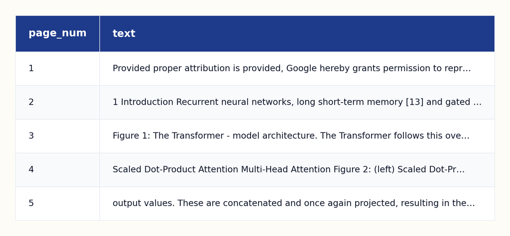

*Caption — page_df_head.png: First five rows of page_df. Each row aggregates every line of a page into a single text field, the unit retrieval scores against.*

#### 2.4.b Keyword matching

For each page, count how many of `parsed_question.keywords` appear in it (case-insensitive substring match). Drop pages with zero matches; keep the top-k by match count. The output table below carries the actual `matched_keywords` per page — anyone can read it and see *why* a page was picked.

```python
retrieved_kw_df, filtered_lines_kw = retrieve_pages(
    page_df, line_df, parsed_question.keywords, top_k=3,
)
print(f"Kept {len(filtered_lines_kw)} lines from pages {retrieved_kw_df['page_num'].tolist()}")
retrieved_kw_df[["page_num", "match_count", "matched_keywords"]]
```

```
Kept 300 lines from pages [6, 8, 9]
```

|  | page_num | match_count | matched_keywords |
| --- | --- | --- | --- |
| 0 | 6 | 1 | [positional encoding] |
| 1 | 8 | 1 | [positional encoding] |
| 2 | 9 | 1 | [positional encoding] |

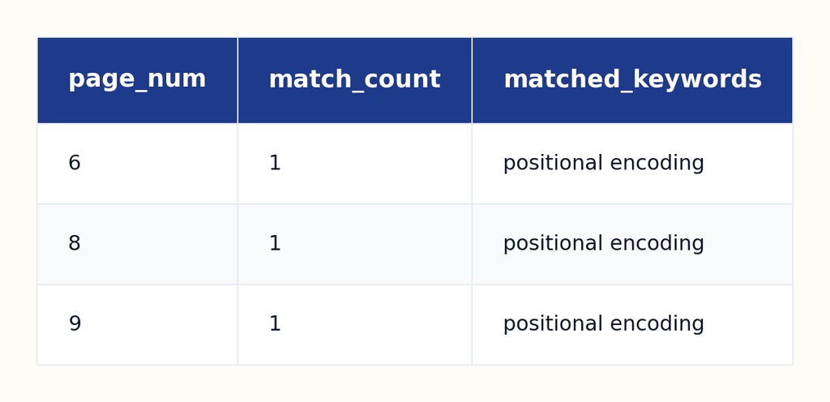

Three pages, ranked by match count, with the actual matches laid out. Pages 6, 8, and 9 each contain the literal phrase `positional encoding`; page 6 holds Section 3.5 *Positional Encoding* with the actual answer. Anyone reading the table can verify the result by hand: search the source for `positional encoding` and you’ll find these three pages.

Two design choices worth flagging:

**We drop pages with zero matches.** When the keyword(s) don’t appear, we’d rather return fewer pages (or none) than pad the result with unrelated material that pollutes the filter sent to generation. A retrieval that says “nothing matches” is more useful than one that says “here are three random pages”. The schema’s null path (next subsection) handles the empty case cleanly.

**Ties are unbroken.** When several pages tie at the same match count, the order is whatever pandas’ `nlargest` returns. We don’t try to rank within the tie. The downstream LLM sees the lines from all three pages in document order and decides.

We’ve reduced the problem from 1048 lines to 300 lines, and we know the right material is in there. Good enough to continue.

```python
filtered_line_df = filtered_lines_kw
```

### 2.5 Generation

Now we send the retrieved lines to the LLM along with the question, and we ask for a structured answer that includes where the evidence comes from. We format the lines as a tab-separated text block, with `page_num` and `line_num` next to each line. We do this on purpose: it gives the LLM the exact coordinates it needs to cite.

> - **In:** the original question, `line_df`, and the retrieved page numbers from §2.4.
> - **Out:** an `AnswerWithEvidence`, a structured JSON with the answer string, the evidence span (`start_page_num`, `start_line_num`, `end_page_num`, `end_line_num`), a confidence, a justification, the exact quotes from the source, and any caveats.

Generation builds `filtered_line_df` on the spot by filtering `line_df` to those pages, so what we save between §2.4 and §2.5 stays small (just page IDs) instead of carrying a heavy DataFrame across.

The raw JSON is worth saving in production: it carries extra info (justification, quotes, caveats, confidence) that later steps (evaluation, audit, replay) all need, well beyond the final `answer` field a chat UI shows.

```python
filtered_text_prompt = "\n".join(
    ["page_num\tline_num\ttext"] +
    filtered_line_df[["page_num", "line_num", "text"]]
    .astype(str).agg("\t".join, axis=1).tolist()
)
print(filtered_text_prompt[:1000])
```

```
page_num    line_num    text
6   1   Table 1: Maximum path lengths, per-layer complexity and minimum number of sequential operations
6   2   for different layer types. n is the sequence length, d is the representation dimension, k is the kernel
6   3   size of convolutions and r the size of the neighborhood in restricted self-attention.
6   4   Layer Type
6   5   Complexity per Layer
6   6   Sequential
6   7   Maximum Path Length
6   8   Operations
6   9   Self-Attention
6   10  O(n2 · d)
6   11  O(1)
6   12  O(1)
6   13  Recurrent
6   14  O(n · d2)
6   15  O(n)
6   16  O(n)
6   17  Convolutional
6   18  O(k · n · d2)
6   19  O(1)
6   20  O(logk(n))
6   21  Self-Attention (restricted)
6   22  O(r · n · d)
6   23  O(1)
6   24  O(n/r)
6   25  3.5
6   26  Positional Encoding
6   27  Since our model contains no recurrence and no convolution, in order for the model to make use of the
6   28  order of the sequence, we must inject some information about the relative or absolute position of the
6   29  tokens in the sequence. To this end, we add "positional encodings" to the input embeddings a
```

**This is what makes the answer grounded**: the model is forced to return not just an answer string, but the precise `(start_page, start_line, end_page, end_line)` of where the evidence comes from, plus a verbatim quote, plus caveats if anything is uncertain. The schema is the contract: the model can’t return prose, only a typed object with citations. With the schema in place, we ask the LLM to fill it. The system message constrains the model to use only the provided lines; the user message hands over the lines and the question; the schema is plugged in via `text_format`.

```python
answer = llm_answer_with_evidence(question, filtered_line_df, client=client)
print(json.dumps(answer.model_dump(), indent=2, ensure_ascii=False))
```

```
{
  "answer": "Sine and cosine functions of different frequencies; learned positional embeddings.",
  "start_page_num": 6,
  "start_line_num": 33,
  "end_page_num": 42,
  "end_line_num": 41,
  "confidence": 0.9,
  "justification": "The lines explain that the authors used sine and cosine functions for positional encoding and also experimented with learned positional embeddings, noting that both versions produced nearly identical results.",
  "quotes": [
    "We chose the sinusoidal version because it may allow the model to extrapolate to sequence lengths longer than the ones encountered during training.",
    "We also experimented with using learned positional embeddings instead, and found that the two versions produced nearly identical results."
  ],
  "caveats": []
}
```

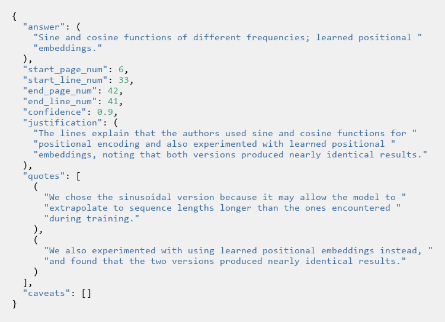

The schema does most of the work. By forcing the LLM to fill specific fields, we constrain it away from the free-form behaviors that produce hallucination. The model can’t ramble or hedge; it has to pick a page number, a line range, and a quote. If it can’t, the schema permits null values and the `caveats` field captures why.

This pattern shows up everywhere in the rest of the series. Article 8 develops it into a much richer schema with per-pillar feedback fields. Part IV extends it to the corpus level. Article 24 builds the storage architecture around it. Here it’s just the starting form: a structured object with explicit “not found” semantics.

### 2.6 PDF annotation on the source PDF

Now the satisfying part. We use the evidence span to draw rectangles directly on the source PDF.

> - **In:** the source PDF and the evidence span from the `AnswerWithEvidence`.
> - **Out:** an annotated PDF with rectangles drawn around the cited lines.
> - **Optional.** A CLI tool, a batch job, or an API may skip it; the answer with citations is already complete after §2.5.

PDF annotation is the rendering step, handy for human review, not part of the core pipeline.

```python
passage_df = passage_lines_df_from_answer(line_df, answer)
bboxes_df = passage_bbox_by_page(passage_df)

out_pdf_path = output_folder / "annotated_passage_rects.pdf"
draw_passage_rectangles(pdf_path, bboxes_df, out_pdf_path)

print(f"Annotated PDF saved to: {out_pdf_path.relative_to(REPO_ROOT)}")
bboxes_df
```

```
Annotated PDF saved to: output\paper\1706.03762v7\annotated_passage_rects.pdf
```

|  | page_num | x0 | y0 | x1 | y1 |
| --- | --- | --- | --- | --- | --- |
| 0 | 6 | 106.834000 | 304.790466 | 505.653900 | 752.295044 |
| 1 | 7 | 107.531990 | 74.176926 | 505.654541 | 752.295044 |
| 2 | 8 | 107.640999 | 71.199478 | 505.245331 | 752.295044 |
| 3 | 9 | 107.531998 | 71.260162 | 505.243744 | 752.295044 |
| 4 | 10 | 107.531998 | 71.275414 | 505.656525 | 752.295044 |
| 5 | 11 | 107.999969 | 74.332306 | 505.747650 | 752.295044 |
| 6 | 12 | 107.999969 | 74.407486 | 505.740479 | 752.295044 |
| 7 | 13 | 108.000000 | 72.787163 | 504.171265 | 752.295044 |
| 8 | 14 | 108.000000 | 170.676544 | 505.387970 | 752.295044 |
| 9 | 15 | 108.000000 | 185.110168 | 504.001495 | 752.295105 |

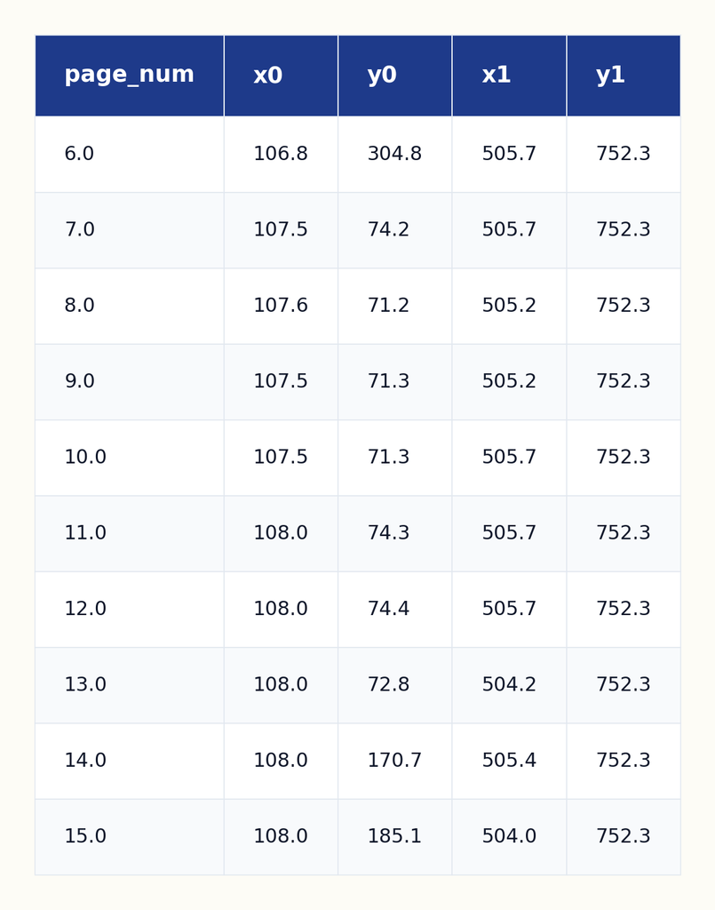

*Caption — bboxes_df.png: One row per cited page, each with the bounding box that wraps the cited lines on that page. `draw_passage_rectangles` consumes this DataFrame and draws each rectangle on its PDF page.*

## 3. Chaining the bricks, and testing the pipeline

With the four bricks (plus PDF annotation) in place, we chain them into a single function `ask_document(pdf_path, question)` (§3.1), then test the pipeline on a different document (§3.2, the World Bank’s April 2026 *Commodity Markets Outlook*) and on a small batch of questions of varied shapes (§3.3) to see how the pipeline behaves across many cases, not just the one we built it on.

### 3.1 The whole pipeline as one function

The bricks chain into a single call. Feed in a PDF and a question; get back a typed answer with line citations, and optionally an annotated PDF with the evidence highlighted.

> - **In:** a PDF path and a text question (plus an optional `top_k` and an optional output PDF path for PDF annotation).
> - **Out:** an `AnswerWithEvidence`, and (if `annotate_pdf` is given) an annotated PDF on disk.

Inside, `ask_document` chains §2.2 → §2.3 → §2.4 → §2.5 → §2.6, with each step’s output passed as the next step’s input. What crosses the §2.4 → §2.5 boundary is just the page numbers; the filtered `line_df` is rebuilt inside §2.5.

```python
from docintel.pipeline import ask_document

answer = ask_document(
    pdf_path=pdf_path,
    question="What are the options mentioned for positional encoding?",
    top_k=3,
    annotate_pdf=output_folder / "annotated_via_ask_document.pdf",
    client=client,
)
print(json.dumps(answer.model_dump(), indent=2, ensure_ascii=False))
```

```
{
  "answer": "Sine and cosine functions of different frequencies, learned positional embeddings",
  "start_page_num": 6,
  "start_line_num": 33,
  "end_page_num": 6,
  "end_line_num": 41,
  "confidence": 0.9,
  "justification": "The lines describe the use of sine and cosine functions for positional encodings and also mention that learned positional embeddings were experimented with, producing nearly identical results to the sinusoidal version.",
  "quotes": [
    "We use sine and cosine functions of different frequencies:",
    "We also experimented with using learned positional embeddings [9] instead."
  ],
  "caveats": []
}
```

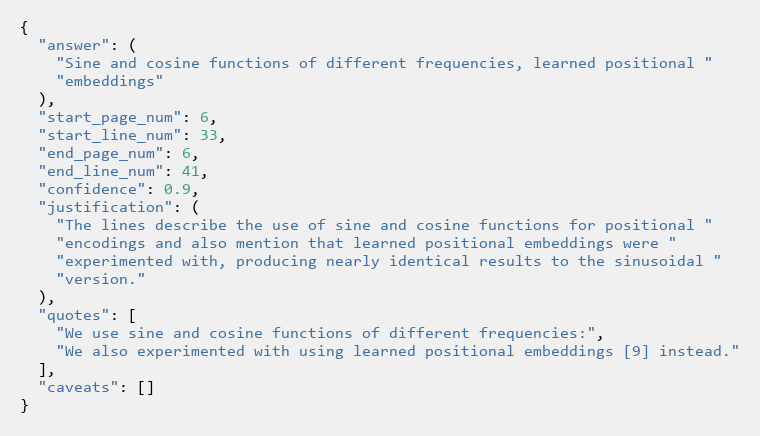

*Caption — ask_document_result.png: The same `AnswerWithEvidence` shape, produced by `ask_document` end to end. Identical schema as §2.5; the difference is the call site (one function instead of five chained steps).*

This is the public API of the article. Everything we built up to this point is now reachable behind a single function call. The signature reads top to bottom: a document, a question, an optional `top_k`, an optional output PDF.

The series uses this function as a recurring reference. Later articles build a sister function `ask_corpus(question, corpus, ...)` for archive-scale work, with the same shape: same contract (typed answer with citations), different scope (filter the corpus first, then run document-level work on the survivors).

### 3.2 Try it on a different document

We ask how much AI-related data centers will contribute to global electricity demand growth. The answer sits on **page 31**, in a sidebar titled *“Upside risk: Artificial intelligence-related power demand”* — the World Bank cites the IEA’’’s projection of **8 percent of global electricity demand growth between 2024 and 2030**.

Same four bricks, same default prompts, same `retrieve_pages`, same schema. Nothing about the pipeline changes for a new document — that’’’s the test.

```python
pdf_path_cmo = REPO_ROOT / "data" / "cmo" / "CMO-April-2026.pdf"
output_folder_cmo = REPO_ROOT / "output" / "cmo" / pdf_path_cmo.stem
output_folder_cmo.mkdir(parents=True, exist_ok=True)

line_df_cmo = fitz_pdf_to_line_df(pdf_path_cmo)
print(f"{len(line_df_cmo)} lines across {line_df_cmo['page_num'].nunique()} pages")
```

```
7297 lines across 61 pages
```

```python
question_cmo = "How much will AI-related data centers contribute to global electricity demand growth?"
parsed_question_cmo = parse_question(question_cmo, client=client)
print(parsed_question_cmo.keywords)
```

```
['AI-related data centers', 'global electricity demand growth']
```

And the same thing in one call via `ask_document`, same shape as §3.1, just pointed at the CMO this time.

```python
answer_cmo_full = ask_document(
    pdf_path=pdf_path_cmo,
    question=question_cmo,
    top_k=3,
    annotate_pdf=output_folder_cmo / "annotated_via_ask_document.pdf",
    client=client,
)
print(json.dumps(answer_cmo_full.model_dump(), indent=2, ensure_ascii=False))
```

```
{
  "answer": "NA",
  "start_page_num": null,
  "start_line_num": null,
  "end_page_num": null,
  "end_line_num": null,
  "confidence": 0.0,
  "justification": "The provided lines do not mention AI-related data centers or their contribution to global electricity demand growth.",
  "quotes": [],
  "caveats": [
    "There is no relevant information about AI-related data centers in the given lines."
  ]
}
```

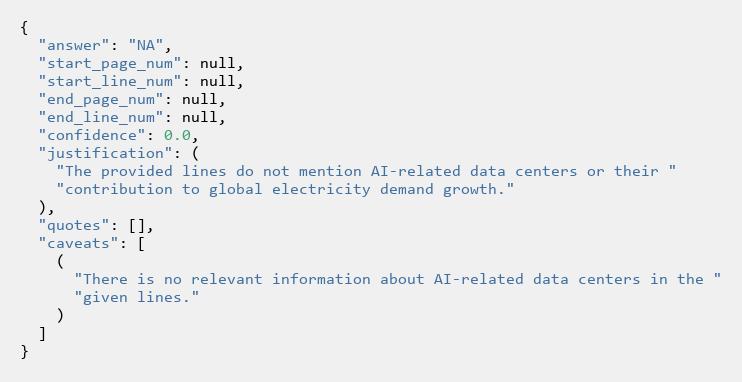

### 3.3 More questions in one table

The four questions we picked:

```python
def run_pipeline_test(
    question: str,
    line_df_in: pd.DataFrame,
    page_df_in: pd.DataFrame,
    page_df_emb_in: pd.DataFrame,
    top_k: int = 3,
    client=client,
) -> dict:
    """Run both retrievers + generation on one question; return a summary dict."""
    parsed_q = parse_question(question, client=client)
    retrieved_emb_df, _ = retrieve_pages_by_similarity(
        page_df_emb_in, line_df_in, question, top_k=top_k, client=client,
    )
    retrieved_kw_df, filtered_lines_kw = retrieve_pages(
        page_df_in, line_df_in, parsed_q.keywords, top_k=top_k,
    )
    # If keyword retrieval finds nothing, fall back to the whole doc so generation
    # still runs (small PDFs only — would not scale to a real corpus).
    lines_for_generation = (
        filtered_lines_kw if len(filtered_lines_kw) > 0 else line_df_in
    )
    answer = llm_answer_with_evidence(
        question, lines_for_generation, client=client,
    )
    return {
        "question": question,
        "keywords": parsed_q.keywords,
        "emb_top3": retrieved_emb_df["page_num"].tolist(),
        "kw_top3": (
            retrieved_kw_df["page_num"].tolist()
            if len(retrieved_kw_df) > 0 else "(no kw match)"
        ),
        "answer_excerpt": (answer.answer[:80] + ("..." if len(answer.answer) > 80 else "")),
        "cite_page": answer.start_page_num,
    }
```

```python
test_cases = [
    # (question, line_df, page_df, page_df_emb)
    (
        "What learning rate is used to train the base Transformer?",
        line_df, page_df, page_df_emb,
    ),
    (
        "What is the chemical composition of seawater?",
        line_df, page_df, page_df_emb,
    ),
    (
        "What is the outlook for urea prices in 2026?",
        line_df_cmo, page_df_cmo, page_df_cmo_emb,
    ),
    (
        "What are the values of d_k and d_v in the Transformer?",
        line_df, page_df, page_df_emb,
    ),
]

sweep_results = pd.DataFrame([
    run_pipeline_test(q, ldf, pdf_, pdf_emb_)
    for q, ldf, pdf_, pdf_emb_ in test_cases
])
sweep_results
```

|  | question | keywords | emb_top3 | kw_top3 | answer_excerpt | cite_page |
| --- | --- | --- | --- | --- | --- | --- |
| 0 | What learning rate is used to train the base T... | [learning rate, base Transformer] | [8, 9, 10] | [7, 9] | lrate = d−0.5 model · min(step_num−0.5, step_n... | 7.0 |
| 1 | What is the chemical composition of seawater? | [chemical composition, seawater] | [14, 15, 13] | (no kw match) |  | NaN |
| 2 | What is the outlook for urea prices in 2026? | [urea prices, outlook, 2026] | [42, 13, 43] | [11, 42, 1] | Urea prices are projected to rise by nearly 60... | 42.0 |
| 3 | What are the values of d_k and d_v in the Tran... | [d_k, d_v, Transformer] | [9, 5, 4] | [1, 2, 3] | /NA | NaN |

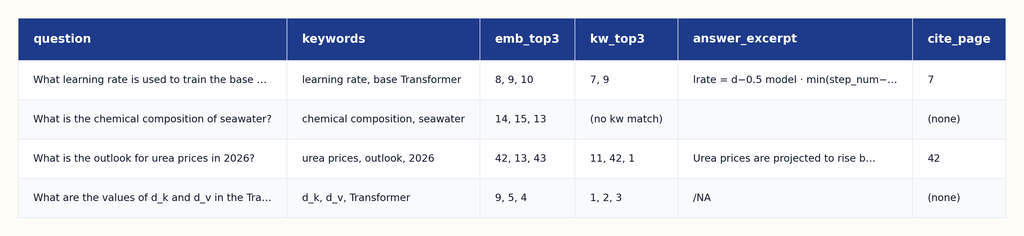

*Caption — sweep_results.png: Same pipeline on four questions: two should succeed (learning rate, urea prices), two should fail (chemical composition of seawater, d_k/d_v). The cite_page column shows what the LLM cited or “(none)” when it correctly refused.*

Two more rows would round this out: a question whose answer is split across pages (tests recall of multi-page evidence) and a question that hits a table cell directly. Article 5 on parsing and Article 6 on question parsing come back to those.

## 4. The questions each block raises

In about a hundred lines of code, with no framework and no vector database, we have a pipeline that takes a PDF and a question, a retrieval step that narrows the document down to a few pages, a generation step that answers using only those pages with citations baked into the answer, and an annotated PDF where the source lines are highlighted.

Before we look at what’s missing, it’s worth pausing on what this minimal system already does well.

**It produces a real, verifiable answer.** Not a paragraph of plausible-sounding text. A structured object with the answer, the page, the lines, the quote. The user can check the citation against the source in seconds.

**It handles “not found” gracefully.** When the answer isn’t in the retrieved lines, the schema allows null fields and the `caveats` field says why. No fabrication.

**It links the answer to the source.** The highlighted PDF closes the loop between the LLM’s claim and the document. This is what separates a useful RAG system from a chatbot that happens to read documents.

**It’s easy to follow.** Someone reading the code can see what each function does in a few minutes. No layers in the way, no hidden state, no framework magic. When something goes wrong (and things will), debugging is reading the code, not digging through layers of code you can’t see into.

Three principles run through it, and they will run through every later article. The work is **pragmatic and expertise-driven**: the four pillars are what an expert would name on a whiteboard, not what a framework imposes. The architecture is **pyramidal**: a reader can trace any answer from question to highlight in a few minutes, no hidden state, no agent loop. The data is **relational at every brick**: `line_df`, `ParsedQuestion`, `retrieved_pages_df`, `AnswerWithEvidence` are all typed structures, never raw strings, every step takes typed input and produces typed output.

Many production RAG systems we’ve seen, including some that cost six figures to build, are worse on these basic things than fifty lines of Python with a careful schema. The extra complexity often makes one thing better at the cost of something else, and teams don’t always notice the trade.

Now look at the same system again, more carefully. Each block hides assumptions worth questioning and failure modes worth seeing — one for each subsection below.

### 4.1 Document parsing: we just read lines

For a question like “What are the options for positional encoding?” this doesn’t matter. The answer is in continuous prose. For a question like “What is the per-layer complexity of self-attention?” it suddenly does, because the answer lives in a table cell that our parser flattened into noise.

That’s the topic of **Article 5: Parsing**. Documents have structure. Ignoring it is the single biggest source of downstream failure.

### 4.2 Question parsing: we asked for keywords, but only keywords

Our question-parsing step extracts a flat list of keywords. That works on a clean question against an academic paper. It starts to leak as soon as questions get harder.

Three things this minimal version doesn’t do.

It doesn’t detect **intent**. “Summarize chapter 3”, “Translate this clause into French”, “Compare X and Y” each call for a different downstream pipeline. A single `keywords` field can’t carry that signal.

It doesn’t decompose **compound questions**. “What are the exclusions and the deductible?” parsed as a flat keyword list pollutes the retrieval (the keywords for “exclusions” and “deductible” pull in two different scopes that interfere). Article 6 walks through how to detect compound questions, decide whether to decompose, and route the sub-questions independently.

It doesn’t surface an **expected answer shape**. “What is the premium amount?” wants a number with a currency. “What are the obligations?” wants a list. “Compare the two policies” wants a table. The minimal version treats every answer as free text. Article 6 introduces the `expected_answer_shape` field that drives the generation template downstream.

That’s the topic of **Article 6: Question Parsing**. The same brick, much richer JSON.

### 4.3 Chunking: we aggregated by page

We chose pages as the unit of retrieval. Why pages? Why not paragraphs, or sections, or fixed-size chunks of 512 tokens like every standard RAG tutorial recommends?

The answer is that page-level aggregation happens to work for this paper because pages roughly align with semantic units. On a contract, on a legal text, on a technical manual with numbered clauses, pages are arbitrary cuts and you’d want clause-level or section-level chunks instead. The “right” chunking depends on the document and the question, not on a default value.

The temptation, when a fixed-size approach starts failing, is to grid-search over chunk sizes and overlaps. That’s the machine learning reflex. It’s the wrong frame for what’s actually a structural decision. **Article 3: RAG Is Not Machine Learning, and the Six-Month Mistake of Treating It Like One** makes that case in full.

### 4.4 Retrieval: keyword matching is transparent, but blind to vocabulary

The trade has a cost. Keyword matching is blind whenever the question’s vocabulary doesn’t match the document’s. Three failure modes show up immediately on the same paper.

**Symbol vs word.** Ask “What is the value of epsilon used in label smoothing?” The keywords from question parsing are likely something like `["epsilon", "label smoothing"]`. The actual answer (`ε_ls = 0.1`) sits on page 8, but the document writes it as the Greek letter `ε`, never the English word “epsilon”. The substring check returns zero on the symbol-only page; only the literal phrase `label smoothing` lands on page 8.

**Synonym mismatch.** Ask “How does the model know the order of words in a sentence?” The keywords might be `["word order", "sentence order"]`. The document calls this *positional encoding*. None of the question’s keywords appear on page 6. The retriever picks pages that happen to mention “order” or “sentence” in passing, none of which contain the answer.

**Paraphrase.** Ask “What attention mechanism does the encoder use?” The document says *self-attention* and *Multi-Head Attention*, never the phrase “attention mechanism the encoder uses”. The keywords pulled from the question, even after expansion, may or may not include the document’s exact phrasing. When they do, retrieval works. When they don’t, it silently degrades.

The first two failures are so common that the rest of the series spends two articles on them. **Article 6: Question Parsing** turns the keyword extraction into a much richer step that pulls from a domain glossary, expands synonyms, and includes likely document phrasings rather than the question’s literal words. **Article 2: Embeddings** introduces vector representations that match across surface vocabulary: where embeddings shine (synonyms, paraphrase, misspellings, cross-lingual matching), where they quietly fail (negation, exact values, internal acronyms, polysemic terms), and how to combine them with keyword matching for the best of both worlds. **Articles 7 and 9** put the resulting hybrid retrieval into a real document index.

The minimal version stays single-retriever because it teaches the right reflex first: *the retriever must be auditable*. Keyword matching makes that reflex concrete (you can see exactly which words landed on which page). Once that reflex is in place, embeddings become a controlled augmentation rather than an opaque default, and combining the two becomes a deliberate engineering choice rather than a fashion.

### 4.5 Generation: we asked for sources, and we got them

That suggests an interesting question: how much more can we ask of this step? Could we ask the model to return a structured comparison if the question is comparative? An explicit “not found” with reasons, instead of a fabricated answer? A list of conflicts if the document contradicts itself? Multiple citations from multiple parts of the document? A confidence breakdown per claim?

Yes to all of the above. The generation step is far more controllable than most teams realize, and most production systems leave it underused. **Article 8: Generation as Controlled Execution** explores this in depth.

## 5. The shape of what comes next

This minimal pipeline is the spine of everything that follows. Each part of the series goes deep on one of the questions raised above.

The misconceptions that wreck most projects come from misframing one of these blocks: RAG isn’t ML (Article 3), embeddings aren’t magic (Article 2), not all RAG problems look the same (Article 4). That’s **Part I**.

Each brick then gets its own deep dive: document parsing, question parsing, retrieval, generation. That’s **Part II**, the four pillars.

Once the blocks are solid, we recombine them for cases that look like production: long documents, justification and absence handling, table-of-contents-driven retrieval, listing questions, structured extraction, the composite pipeline. That’s **Part III**.

Then we change scale. From one document to many. From a single paper to an archive of hundreds or thousands of documents. The architecture changes substantially. That’s **Part IV**.

Finally, what it takes to operate the system in production: evaluation, cost and monitoring, security and compliance, the architecture of the codebase itself. That’s **Part V**.

**The blocks don’t change. Their internals do.**

Two reading hints, while we’re here.

**The four pillars (Part II) are the conceptual core.** Document parsing, question parsing, retrieval, generation. The minimal version above does each in the simplest way possible. Most of the rest of the series is about doing them better. Once you understand the four pillars, the articles in Part III and Part IV are recombinations of them: the same four ideas, applied at different scales and for different question types.

**The series scope is enterprise documents.** The example above runs on a structured arXiv paper with a clear sectioning. Real enterprise corpora share the same property: contracts, technical specs, regulatory filings, internal procedures, all carry structure (a TOC, sections, tables, recurring layouts) and a bounded vocabulary (industry jargon, expert terms, company-specific codes). The tractability of RAG on those corpora comes from that structure, not from heroic embedding tricks. Cases where the document has no structure at all (a novel, a long unstructured transcript) and the question requires understanding intent rather than locating a passage (detect every sarcastic line, classify the narrator’s mood) are out of scope; Article 4 returns to where the line falls.

**Code in this series is illustrative, not always production-ready.** What you’ve just read works on a real PDF, but it lacks the error handling, the validation, the caching, the cost controls, the monitoring, the security checks that a production system needs. We treat each of these explicitly when their article arrives. Until then, the code in each article prioritizes being clear and runnable over being bulletproof.

Here’s the explicit map from this minimal system to the rest of the series:

- **PDF parsing throws away structure** → Article 5, Article 10
- **Question parsing needs more than keywords** (intent, decomposition, expected answer shape) → Article 6
- **Chunking strategy isn’t a hyperparameter** → Article 3
- **Question vocabulary doesn’t match document terms** → Article 2, Article 6
- **Retrieval picks the wrong page** → Article 7, Article 9
- **Model paraphrases its citation** → Article 8, Article 22
- **“Not found” needs nuance** → Article 4
- **Compound, listing, comparison, summarization questions** → Article 6, Articles 11-14
- **Multi-document corpus** → Part IV (Articles 16-21)
- **Production, evaluation, security, architecture** → Part V (Articles 22-25)

## Summary

About a hundred lines of Python (four bricks plus PDF annotation, six packages) produce a working RAG system on a real PDF. Parse the document into a `line_df` with bounding boxes. Parse the question into a small list of retrieval-friendly keywords. Aggregate the document into one text block per page, count keyword matches per page, keep the top-k. Ask the LLM with a Pydantic schema that forces structured citations. Highlight the cited region on the original PDF.

What this minimal version gets right matters. Structured output keeps the answer verifiable. The schema’s null path makes “not found” a first-class outcome instead of a cause of fabrication. The PDF highlight closes the loop between claim and source. The whole thing is small enough to read top-to-bottom in a few minutes, which means small enough to debug, modify, and trust.

It is also striking how thin the ice is. Change the question slightly (ask about *epsilon* in label smoothing when the document writes the Greek letter `ε`) and the keyword retriever has nothing to grab onto: the page that contains the answer scores zero. Change the document slightly (a scanned PDF, a table-heavy report, a long contract), and parsing starts losing critical structure. Add ten more documents, and “look for the question’s words on every page” stops being a sane strategy.

Two themes will recur throughout the series. First, the four pillars (document parsing, question parsing, retrieval, generation) are the conceptual core. The minimal version touches each in the simplest way possible. Most of what follows is about doing each better, recombining them, scaling them up. Second, **the structure of an answer is the structure of trust**. As long as the system produces a typed, cited, verifiable answer with a clean “not found” path, users can rely on it. When that structure breaks down, trust collapses with it: the answer becomes prose, citations drift, “not found” looks the same as a wrong answer, and the system stops being useful regardless of how clever the retrieval is.

The minimal version is a baseline, not a destination. The rest of the series is about turning this baseline into something that holds up in production.

The next article takes a step back from the working system and addresses a misconception that derails many RAG projects: the idea that RAG is a machine learning problem. It isn’t, and treating it as one wastes effort on the wrong things while leaving the things that actually matter unaddressed.